# Linear model forecasting of Uber

```r
source('uber_data_preprocessing.R')
```

```r
source('error_metrics.R')
```

In this notebook, I will fit several linear models with time series components. I will investigate how the models will perform and will evaluate their error metric and residuals. Models that I will investigate are 1) linear model with a trend, 2) piecewise linear model with different trends, 3) quadratic model, 4) linear model with exponential trend, 5) natural cubic smoothing spline, and 6) all previous models with the inclusion of harmonics (Fourier terms) for modeling the seasonality.

First, let's take a look at the ren sequence plot of the data.

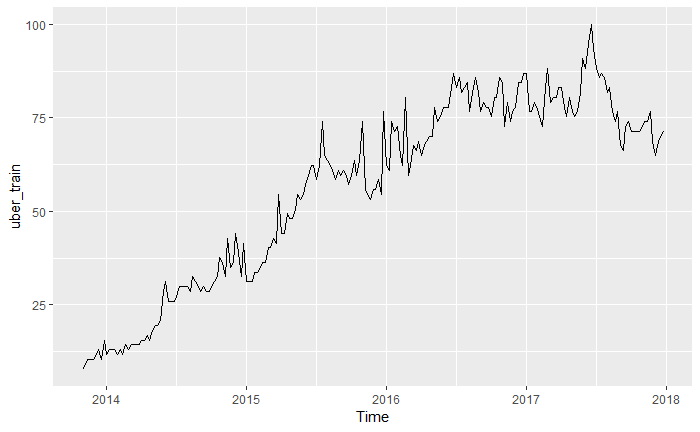

```r
autoplot(uber_train)
```

As seen, from approximately June 2016, the trend of the data changes. Prior to this date, we can see an almost increasing linear trend. However, after this date, the trend gradually decreases. As a result, fitting the linear model (constant slope) might not be the best choice and therefore piecewise linear model (with a break at June 2016) or linear model with second order polynomials might be better choices. I will explore all of these models.

```r
# linear model
linear_model <- tslm(uber_train ~ trend)
# piecewise linear model
t <- time(uber_train)
t_break <- 2016.50
tb <- ts(pmax(0,t-t_break), start = c(2013,44))
pw_linear_model <- tslm(uber_train ~ t + tb)
# linear model with second order polynomials
quad_model <- tslm(uber_train ~ t + I(t^2))
# linear model with exponential trend
exp_model <- tslm(uber_train ~ trend, lambda=0)
# natural cubic smoothing splines
spline_model <- tslm(uber_train ~ t + I(t^2) + I(t^3) + I(tb^3) + I(tb^3))
```

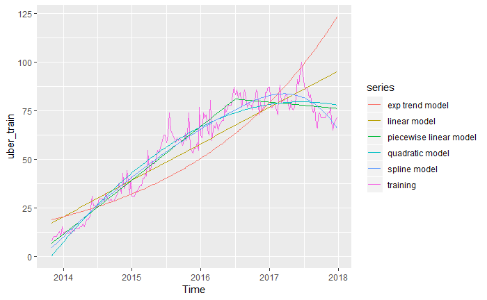

```r
# showing how models fit the data
autoplot(uber_train, series = 'training')+
  autolayer(fitted(linear_model), series='linear model')+
  autolayer(fitted(pw_linear_model), series='piecewise linear model')+
  autolayer(fitted(quad_model), series='quadratic model')+
  autolayer(fitted(exp_model), series='exp trend model')+
  autolayer(fitted(spline_model), series='spline model')
```

As expected, the linear model with constant slope does not seem to be a good fit. The linear model with exponential trend seems very off. Quadratic model and spline models seem to be fine (spline might have been overfitted). However, the piecewise linear model seems the most appropriate one to me. Let's take a look at their accuracy.

```r
accuracy(linear_model)
```

```
                        ME     RMSE     MAE       MPE     MAPE     MASE
Training set -1.042881e-15 10.01746 7.95678 -8.686781 19.94268 0.370057
```

```r
accuracy(pw_linear_model)
```

```
                        ME     RMSE      MAE       MPE     MAPE      MASE
Training set -2.293632e-16 5.728781 4.469488 -1.033058 9.235567 0.2078687
```

```r
accuracy(quad_model)
```

```
                        ME    RMSE     MAE       MPE     MAPE      MASE
Training set -4.001176e-16 6.32261 5.10728 0.7774528 12.35193 0.2375314
```

```r
accuracy(exp_model)
```

```
                    ME    RMSE      MAE       MPE     MAPE    MASE
Training set -51.92853 59.4488 51.92853 -1277.013 1277.013 101.667
```

```r
accuracy(spline_model)
```

```
                        ME     RMSE      MAE        MPE     MAPE      MASE
Training set -8.584483e-17 5.521554 4.461154 -0.4476426 9.981576 0.2074811
```

The metric values suggest that piecewise linear, quadratic, and spline models worth further investigation. As explained in the previous notebook, a week to medium seasonality exists in the data. As a result, I utilize the three aforementioned models and include the Fourier terms to model the seasonality. In order to find the best order of Fourier terms, I will do a grid search.

```r
# Calculating the best order for fourier for the three models
best_aicc <- Inf
bestK <- 1
for(K in seq(25)) {
  fit <- tslm(uber_train ~ t + tb + fourier(uber_train, K=K))
 # fit <- tslm(uber_train ~ t + I(t^2) + fourier(uber_train, K=K))
 # fit <- tslm(uber_train ~ t + I(t^2) + I(t^3) + I(tb^3) + I(tb^3) + fourier(uber_train, K=K))
  aicc <- as.numeric(CV(fit)[['AICc']])
  if(aicc < best_aicc) {
    best_aicc <- aicc
    bestK <- K
  }
}
print(bestK)
```

```
[1] 3
```

It turns out that the best Fourier order for the three models is three (note that two models are commented in the code). Hence, I will build three harmonic models and evaluate them.

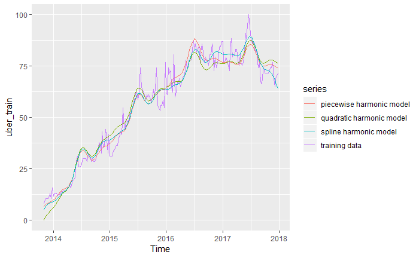

```r
harm <- fourier(uber_train, K=3)
pw_harmonic_model <- tslm(uber_train ~ t + tb + harm)
quad_harmonic_model <- tslm(uber_train ~ t + I(t^2) + harm)
spline_harmonic_model <- tslm(uber_train ~ t + I(t^2) + I(t^3) + I(tb^3) + I(tb^3) + harm)
autoplot(uber_train, series = 'training data')+
  autolayer(fitted(pw_harmonic_model), series='piecewise harmonic model')+
  autolayer(fitted(quad_harmonic_model), series='quadratic harmonic model')+
  autolayer(fitted(spline_harmonic_model), series='spline harmonic model')
```

It seems that all of the three models are doing good (they might have been over-fitted actually, so I will explore this). However, for the spline model, it seems that its trend is going down for the year 2018 significantly (which might be dangerous a bit). Now let's look at the performance of the models.

```r
accuracy(pw_harmonic_model)
```

```
                        ME    RMSE      MAE        MPE     MAPE      MASE
Training set -4.745888e-16 4.73625 3.677246 -0.2256244 7.883928 0.1710228
```

```r
accuracy(quad_harmonic_model)
```

```
                        ME    RMSE      MAE      MPE     MAPE      MASE
Training set -1.419475e-16 5.41769 4.293383 1.489114 11.48023 0.1996783
```

```r
accuracy(spline_harmonic_model)
```

```
                       ME    RMSE      MAE       MPE     MAPE     MASE
Training set 1.842284e-16 4.45225 3.383711 0.2649486 7.979103 0.157371
```

In comparison with the same models but without harmonic terms, it seems that the performance has been improved considerably. In order to select the best model, I will use the rolling based cross-validation and compare the RMSE values.

```r
fpwharm <- function(x,h){
  t <- time(x)
  t_break <- 2016.50
  tb <- ts(pmax(0,t-t_break), start = c(2013,44))
  harm <- fourier(x, K=3)
  fit <- tslm(x ~ t + tb + harm)
  t_new <- t[length(t)] + seq(0.01923077,by=0.01923077, length.out = h)
  tb_new <- tb[length(tb)] + seq(0.01923077,by=0.01923077, length.out = h)
  newdata <- cbind(t=t_new, tb=tb_new, harm=fourier(x, K=3, h=h)) %>% as.data.frame()
  return(forecast(fit, newdata = newdata, h=h))
}
fquadharm <- function(x,h){
  t <- time(x)
  t2 <- I(t^2)
  harm <- fourier(x, K=3)
  fit <- tslm(x ~ t + t2 + harm)
  t_new <- t[length(t)] + seq(0.01923077,by=0.01923077, length.out = h)
  t2_new <-I(t_new^2)
  newdata <- cbind(t=t_new, t2=t2_new, harm=fourier(x, K=3, h=h)) %>% as.data.frame()
  return(forecast(fit, newdata = newdata, h=h))
}
fsplineharm <- function(x,h){
  t <- time(x)
  t2 <- I(t^2)
  t3 <- I(t^3)
  t_break <- 2016.50
  tb <- ts(pmax(0,t-t_break), start = c(2013,44))
  tb2 <- I(tb^2)
  tb3 <- I(tb^3)
  t_new <- t[length(t)] + seq(0.01923077,by=0.01923077, length.out = h)
  t2_new <- I(t_new^2)
  t3_new <- I(t_new^3)
  tb_new <- tb[length(tb)] + seq(0.01923077,by=0.01923077, length.out = h)
  tb2_new <- I(tb_new^2)
  tb3_new <- I(tb_new^3)
  harm <- fourier(x, K=3)
  fit <- tslm(x ~ t + t2 + t3 + tb + tb2 + tb3 + harm)
  newdata <- cbind(t=t_new, t2=t2_new, t3=t3_new,
                   tb=tb_new, tb2 = tb2_new, tb3=tb3_new,
                   harm=fourier(x, K=3, h=h)) %>% as.data.frame()
  return(forecast(fit, newdata = newdata, h=h))
}
```

```r
tsCV(uber_train, fpwharm, h=1) %>% tsclean() %>% rmse()
```

```
[1] 5.410764
```

```r
tsCV(uber_train, fquadharm, h=1) %>% tsclean() %>% rmse()
```

```
[1] 5.964817
```

```r
tsCV(uber_train, fsplineharm, h=1) %>% tsclean() %>% rmse()
```

```
[1] 5.716291
```

As seen, the piecewise harmonic model delivers a lower RMSE value on cross-validation. In addition to the RMSE value, I believe using the piecewise linear model would be safer because the trend does not change dramatically compared to the quadratic and spline models. Therefore, the selected linear model would be the piecewise linear with harmonics of order 3. Now let's take a look at the residuals.

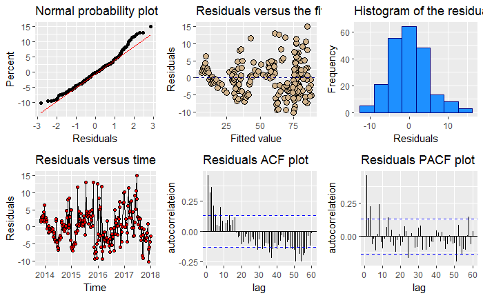

```r
residual_diagnostics_plots(pw_harmonic_model)
```

As seen in the residual diagnostics plots, the model does not pass the residual requirements. There are significant auto-correlations left in the ACF and PACF plots. The variation of the residuals over time changes considerably. Residual vs fitted value plot shows obvious structure. As a result, I believe this model is not the best possible approach. However, just for the sake of illustration, I am going to show the forecast for this model.

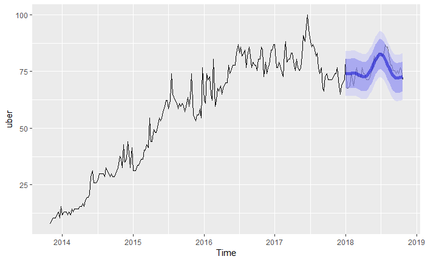

```r
t_new <- t[length(t)] + seq(0.01923077,by=0.01923077, length.out = length(uber_test))
tb_new <- tb[length(tb)] + seq(0.01923077,by=0.01923077, length.out = length(uber_test))
newdata <- cbind(t=t_new, tb=tb_new, harm=data.frame(fourier(uber_train, K=3, h=length(uber_test)))) %>% as.data.frame()
pw_harmonic_fcst <- forecast(pw_harmonic_model, newdata = newdata, h=length(uber_test))
autoplot(uber)+
  autolayer(pw_harmonic_fcst, alpha=0.5, size=2)
```

In fact, it can be argued that the model performs well on the testing set. Let’s take a look at the error metrics.

```r
accuracy(pw_harmonic_fcst, uber)
```

```
                        ME     RMSE      MAE        MPE     MAPE      MASE      ACF1 Theil's U
Training set -4.745888e-16 4.736250 3.677246 -0.2256244 7.883928 0.1799121 0.4613361        NA
Test set      6.652903e-01 3.374512 2.670787  0.6609870 3.515496 0.1306703 0.5322661  1.029414
```

The results of the testing set are very good. However, based on residuals plots and cross-validation results, I believe this model is not the most appropriate one. In the next notebook, I will explore exponential smoothing models. Stay tuned.